# Ds220_Project_2

This comprehensive analysis delves into the intricate dynamics of global economies, seeking to unearth pivotal relationships between population metrics, GDP, and unemployment rates across various continents."

Utilizing the robust capabilities of Pandas and Matplotlib, we streamline our data manipulation and visualization processes for optimal clarity and efficiency."

```python
import pandas as pd
import numpy as np
import matplotlib.pyplot as plt
```

```python
data = pd.read_csv('Victoria2EconomyData.csv')
data
```

|  | year | tag | countryName | population | gdp | rgoUnemploymentRate | factoryUnemploymentRate | rgoWorkforce | factoryWorkforce | continent | gdpPerCapita | totalPercentageOfUnemployed |
| --- | --- | --- | --- | --- | --- | --- | --- | --- | --- | --- | --- | --- |
| 0 | 1993 | AAB | Antigua And Barbuda | 65056 | 1.361235e+08 | 1.793132 | 100.000000 | 14444 | 696 | North America | 2092 | 6.3 |
| 1 | 1993 | ABK | Abkhazia | 528720 | 1.984037e+09 | 1.281237 | 3.942280 | 110206 | 10603 | Asia | 3753 | 1.5 |
| 2 | 1993 | ABZ | Ambazonia | 0 | 0.000000e+00 | 0.000000 | 0.000000 | 0 | 0 | Africa | 0 | 0.0 |
| 3 | 1993 | AFG | Afghanistan | 14045836 | 2.346005e+10 | 2.154671 | -11.588917 | 3069193 | 121737 | Asia | 1670 | 1.7 |
| 4 | 1993 | AGI | Anguilla | 8972 | 9.630000e+04 | 0.000000 | -131.578950 | 2005 | 19 | North America | 11 | -1.2 |
| ... | ... | ... | ... | ... | ... | ... | ... | ... | ... | ... | ... | ... |
| 9457 | 2029 | ALA | Aland | 25036 | 3.522695e+09 | 0.050684 | 1.018221 | 3946 | 1866 | Europe | 140705 | 0.4 |
| 9458 | 2029 | YUG | Yugoslavia | 0 | 0.000000e+00 | 0.000000 | 0.000000 | 0 | 0 | Europe | 0 | 0.0 |
| 9459 | 2030 | FIN | Finland | 4908196 | 1.950000e+11 | 2.230920 | 7.309435 | 610914 | 474852 | Europe | 39765 | 4.4 |
| 9460 | 2030 | LBY | Libya | 7874224 | 2.244429e+10 | 8.334998 | -2.443996 | 1406719 | 224714 | Africa | 2850 | 6.8 |
| 9461 | 2030 | SOT | South Ossetia | 111232 | 4.383612e+09 | 3.706106 | 61.234104 | 20048 | 4246 | Asia | 39410 | 13.7 |

9462 rows × 12 columns

This is just to clean and also process the data.

```python
print(data.isnull().sum())
data.drop_duplicates(inplace=True)
data.to_csv('Victoria2EconomyData1.csv', index=False)
```

```
year                           0
tag                            0
countryName                    0
population                     0
gdp                            0
rgoUnemploymentRate            0
factoryUnemploymentRate        0
rgoWorkforce                   0
factoryWorkforce               0
continent                      0
gdpPerCapita                   0
totalPercentageOfUnemployed    0
dtype: int64
```

```python
data1 = pd.read_csv('Victoria2EconomyData1.csv')
data1
```

|  | year | tag | countryName | population | gdp | rgoUnemploymentRate | factoryUnemploymentRate | rgoWorkforce | factoryWorkforce | continent | gdpPerCapita | totalPercentageOfUnemployed |
| --- | --- | --- | --- | --- | --- | --- | --- | --- | --- | --- | --- | --- |
| 0 | 1993 | AAB | Antigua And Barbuda | 65056 | 1.361235e+08 | 1.793132 | 100.000000 | 14444 | 696 | North America | 2092 | 6.3 |
| 1 | 1993 | ABK | Abkhazia | 528720 | 1.984037e+09 | 1.281237 | 3.942280 | 110206 | 10603 | Asia | 3753 | 1.5 |
| 2 | 1993 | ABZ | Ambazonia | 0 | 0.000000e+00 | 0.000000 | 0.000000 | 0 | 0 | Africa | 0 | 0.0 |
| 3 | 1993 | AFG | Afghanistan | 14045836 | 2.346005e+10 | 2.154671 | -11.588917 | 3069193 | 121737 | Asia | 1670 | 1.7 |
| 4 | 1993 | AGI | Anguilla | 8972 | 9.630000e+04 | 0.000000 | -131.578950 | 2005 | 19 | North America | 11 | -1.2 |
| ... | ... | ... | ... | ... | ... | ... | ... | ... | ... | ... | ... | ... |
| 9457 | 2029 | ALA | Aland | 25036 | 3.522695e+09 | 0.050684 | 1.018221 | 3946 | 1866 | Europe | 140705 | 0.4 |
| 9458 | 2029 | YUG | Yugoslavia | 0 | 0.000000e+00 | 0.000000 | 0.000000 | 0 | 0 | Europe | 0 | 0.0 |
| 9459 | 2030 | FIN | Finland | 4908196 | 1.950000e+11 | 2.230920 | 7.309435 | 610914 | 474852 | Europe | 39765 | 4.4 |
| 9460 | 2030 | LBY | Libya | 7874224 | 2.244429e+10 | 8.334998 | -2.443996 | 1406719 | 224714 | Africa | 2850 | 6.8 |
| 9461 | 2030 | SOT | South Ossetia | 111232 | 4.383612e+09 | 3.706106 | 61.234104 | 20048 | 4246 | Asia | 39410 | 13.7 |

9462 rows × 12 columns

**First Question**

Which country has the highest gdp?

```python
max_gdp = data1.loc[data['gdp'].idxmax(), 'countryName']
print(max_gdp)
```

```
China
```

**Second Querstion**

```python
max_gdp_per_capita_country = data.loc[data['gdpPerCapita'].idxmax(), 'countryName']
print(max_gdp_per_capita_country)
```

```
Nauru
```

**Third Question**

How population affect GDP?

```python
population_gdp_correlation = data['population'].corr(data['gdp'])
print(population_gdp_correlation)
```

```
0.9127200648214594
```

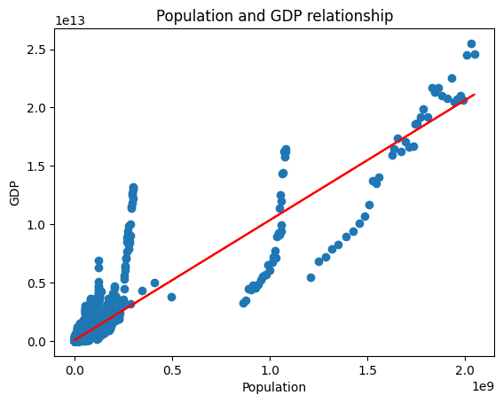

```python
m, b = np.polyfit(data1['population'], data1['gdp'], 1)
plt.plot(data1['population'], m * data1['population'] + b, color='red')
plt.scatter(data1['population'], data1['gdp'])
plt.title('Population and GDP relationship')
plt.xlabel('Population')
plt.ylabel('GDP')
plt.show()
```

The substantial correlation between population size and GDP underscores the importance of human capital in driving economic expansion. In nations where population growth is coupled with strategic economic planning and development, the increase in human resources can translate into higher productivity and economic output, as reflected by GDP. This positive association, however, is not a universal rule and must be understood in context; an expanding population may not lead to economic growth without the necessary infrastructure, education, and employment opportunities. It is the interplay between population growth and these factors that shapes the trajectory of a country's economic prosperity.

**Fourth Question**

How does the level of industrialization in different countries affect their economic performance?

```python
data1['industrializationLevel'] = data1['factoryWorkforce'] / data1['population']
industrialization_gdp_correlation = data1['industrializationLevel'].corr(data1['gdp'])
print(industrialization_gdp_correlation)
data1.loc[data1['industrializationLevel'].isna(), 'industrializationLevel'] = 0
```

```
0.014579724614579324
```

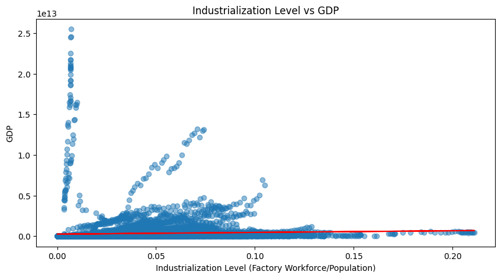

```python
plt.figure(figsize=(10, 5))
plt.scatter(data1['industrializationLevel'], data1['gdp'], alpha=0.5)  # Plot the data points
m, b = np.polyfit(data1['industrializationLevel'], data1['gdp'], 1)  # Fit a line to the data
plt.plot(data1['industrializationLevel'], m * data1['industrializationLevel'] + b, color='red')  # Plot the line of best fit
plt.title('Industrialization Level vs GDP')
plt.xlabel('Industrialization Level (Factory Workforce/Population)')
plt.ylabel('GDP')
plt.show()
```

The analysis reveals a surprisingly weak correlation between industrialization levels and GDP, challenging common assumptions about the direct impact of industrialization on economic performance. This indicates that other factors may play a more significant role in a nation's economic prosperity. The data suggests that merely increasing industrial activity does not guarantee a corresponding increase in GDP, pointing to the complexity of economic ecosystems. It implies that while industrialization can contribute to economic growth, its role is nuanced and potentially overshadowed by other economic activities or inefficiencies. This finding prompts a reevaluation of development strategies, advocating for a more holistic approach that goes beyond industrial output to include innovation, service sector development, and economic diversification.

**Fifth Question**

What is the difference in unemployment rates between agricultural workers (rgoWorkforce) and factory workers (factoryWorkforce)?

```
Average unemployment rate for agricultural workers (rgoWorkforce): 6.575516131249207
Average unemployment rate for factory workers (factoryWorkforce): 1.2805983981242868
```

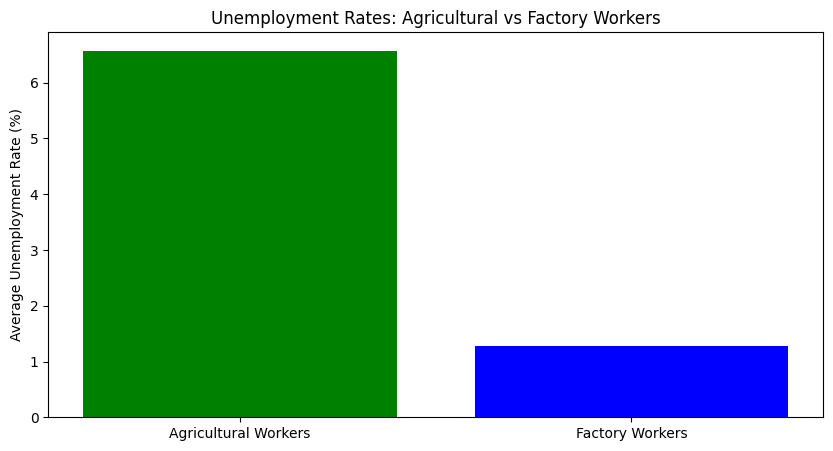

```python
avg_rgo_unemployment_rate = data1['rgoUnemploymentRate'].mean()
avg_factory_unemployment_rate = data1['factoryUnemploymentRate'].mean()
print(f"Average unemployment rate for agricultural workers (rgoWorkforce): {avg_rgo_unemployment_rate}")
print(f"Average unemployment rate for factory workers (factoryWorkforce): {avg_factory_unemployment_rate}")
labels = ['Agricultural Workers', 'Factory Workers']
unemployment_rates = [avg_rgo_unemployment_rate, avg_factory_unemployment_rate]
plt.figure(figsize=(10, 5))
plt.bar(labels, unemployment_rates, color=['green', 'blue'])
plt.title('Unemployment Rates: Agricultural vs Factory Workers')
plt.ylabel('Average Unemployment Rate (%)')
plt.show()
```

The disparity in unemployment rates between agricultural and factory workers highlights the relative stability of manufacturing jobs compared to agriculture. This could be attributed to various factors including the seasonal nature of farming, the vulnerability of agriculture to climatic and economic variables, and the ongoing mechanization and consolidation of agricultural enterprises, which often leads to reduced labor needs. Conversely, factory jobs, often underpinned by more consistent production schedules and less susceptibility to seasonal changes, tend to offer more reliable employment throughout the year. This suggests that industrial jobs may provide a more stable economic foundation for workers, reflecting broader trends in employment stability across sectors.

**Sixth Question**

Which country has the highest unemployment rate, and what is its relationship to GDP?

```python
country_with_highest_unemployment = data.loc[data['totalPercentageOfUnemployed'].idxmax()]
print(f"Country with the highest unemployment rate: {country_with_highest_unemployment['countryName']}")
print(f"Unemployment rate: {country_with_highest_unemployment['totalPercentageOfUnemployed']}")
print(f"GDP: {country_with_highest_unemployment['gdp']}")
correlation_unemployment_gdp = data['totalPercentageOfUnemployed'].corr(data['gdp'])
print(f"Correlation between unemployment rate and GDP: {correlation_unemployment_gdp}")
```

```
Country with the highest unemployment rate: Comoros
Unemployment rate: 100.0
GDP: 1586367200.0
Correlation between unemployment rate and GDP: 0.04755244077843259
```

The minimal correlation between unemployment rates and GDP indicates that the two metrics may be influenced by a complex array of factors beyond a direct cause-and-effect relationship. This could suggest that high GDP does not necessarily equate to low unemployment, as economic wealth may not be evenly distributed across a workforce. Similarly, low unemployment does not guarantee a high GDP, as a large number of employed individuals may be working in low-productivity sectors or informal economies. This nuanced view challenges simplistic economic models and calls for a multifaceted approach to understanding economic health.